# Song alignment

- Show All Code
- Hide All Code
- View Source

Choosing the MAFFT scores and aligning the 5 ms song sequences

Author

[Marcelo Araya-Salas](https://marce10.github.io/)

Published

November 7, 2026

# Purpose

Align the 5 ms song sequences and prepare them for RevBayes:

1. Find the scores MAFFT should give to each pair of song states, which define the “optimal” alignment strategy. **Adopted scores: different category = -2, same category = -0.75, same state = 2** ($r$ = 0.3125, explained below)
2. Align the songs of the five leks in the paper with three strategies: MAFFT-optimal, MAFFT-agnostic and PRANK
3. Build the datasets for the analyses, which use all the years of each song type (`all`) or only its first and last year (`bounds`), and save them as nexus files

# Load packages

```r
sketchy::load_packages(packages = c("knitr", "ggplot2", "viridis"))

theme_set(theme_classic(base_size = 13))
knitr::opts_chunk$set(message = FALSE, warning = FALSE, dpi = 120, fig.retina = 1)

in_dir <- "./data/processed/mafft_optimization_5ms"
n_expected <- 596          # number of score combinations in the full run
paper_leks <- c("BR1", "CCE", "HC1", "SUR", "TR1")
```

# 1 Choosing the MAFFT scores

An alignment places similar parts of different songs in the same column, adding gaps where needed. MAFFT decides how to do this using a **score** for each pair of states: the higher the score, the more willing it is to align those two states.

There is no reference alignment of bird songs to tell us which scores are correct, so we use an indirect criterion. Songs of the same lek share ancestry and should have parts in common, whereas songs assembled at random should not. Good scores should therefore align real songs with few gaps and need many more gaps for simulated songs. The optimal scores are the ones that **best separate simulated from real songs in the amount of gaps**.

The procedure has four steps:

1. **Simulate songs** with the same building blocks and lengths as the real songs, but in random order
2. **Set up a grid of scores** for three kinds of state pairs
3. **Align** real and simulated songs with every combination of scores
4. **Choose** the scores that best separate real from simulated songs

# 2 Songs

## 2.1 Real songs

Each song type is represented by its most representative recording. As only leks with enough song types give a useful alignment, we use the leks with more than 5 song types. This includes leks that are not in the paper, which gives more alignments to estimate the scores.

```r
dat <- read.csv("./data/processed/song_5ms_sequences_by_song_type_all_leks.csv", stringsAsFactors = FALSE)
tb <- table(dat$lek)
leks <- names(tb)[tb > 5]
dat <- dat[dat$lek %in% leks, ]

data.frame(lek = leks, song_types = as.vector(table(dat$lek)),
           used_in_the_paper = ifelse(leks %in% paper_leks, "yes", "no"),
           min_length = as.vector(tapply(nchar(dat$sequence), dat$lek, min)),
           max_length = as.vector(tapply(nchar(dat$sequence), dat$lek, max)))
```

| lek | song_types | used_in_the_paper | min_length | max_length |
| --- | --- | --- | --- | --- |
| BR1 | 12 | yes | 27 | 34 |
| CCE | 21 | yes | 25 | 37 |
| CCL | 18 | no | 22 | 35 |
| HC1 | 20 | yes | 21 | 31 |
| HC2 | 11 | no | 25 | 36 |
| LOC | 9 | no | 27 | 32 |
| SAT | 13 | no | 24 | 33 |
| SJA | 13 | no | 20 | 43 |
| SUR | 38 | yes | 22 | 38 |
| TR1 | 13 | yes | 18 | 32 |
| TR2 | 8 | no | 27 | 35 |

## 2.2 Simulated songs

Each real song is cut into **runs**, stretches of the same state. Simulated songs are built by drawing runs at random from all of the runs found in the real songs, with no two consecutive runs of the same state. The simulated songs have the same kinds of sounds in the same proportions as real songs, but not their order.

Each simulated lek has the same number of songs as the real lek, and the same song lengths. Any difference in gaps therefore comes from the order of the sounds. There are 100 simulated versions of each lek.

```r
sim_sets <- readRDS(file.path(in_dir, "simulated_song_sets.RDS"))
lexic <- readLines(file.path(in_dir, "song_state_lexicon.txt"))

data.frame(runs_in_real_songs = length(lexic), median_run_length = median(nchar(lexic)),
           simulated_sets = length(sim_sets))
```

| runs_in_real_songs | median_run_length | simulated_sets |
| --- | --- | --- |
| 1007 | 3 | 100 |

```r
data.frame(song = c("real", "real", "simulated", "simulated"),
           sequence = c(dat$sequence[dat$lek == "BR1"][1:2], sim_sets[[1]][["BR1"]][1:2]))
```

| song | sequence |
| --- | --- |
| real | ffffffffffffffffddddddddddddp |
| real | upduussssssssssuppddddddddd |
| simulated | ufffffffffdduusssssssssssssup |
| simulated | dddddpddssssssssssuuddppppd |

# 3 The scores

States are grouped in two categories, trills (f, s) and pure tones (d, p, u), which gives three kinds of pairs. Each has its own score:

| Pair | Example | Score |
| --- | --- | --- |
| Same state | f with f | `same.state` |
| Different states in the same category | f with s, or d with u | `same.category` |
| States in different categories | f with d | `different.category` |

As in the previous optimization, scores range from -2 to 2 in steps of 0.25, always increase (`different.category` < `same.category` < `same.state`), and the score for the same state is positive. This gives 596 combinations.

# 4 Aligning real and simulated songs

Each lek is aligned with every combination, using `mafft --localpair --maxiterate 10000 --textmatrix` (L-INS-i, MAFFT v7.526), in `source/optimize_mafft_costs_5ms.R`. Gap opening and extension penalties are the MAFFT defaults. With 11 real leks and 100 versions of 11 simulated leks, there are 1,111 alignments per combination.

Two measures are taken from each alignment:

- **Gaps**: the number of columns added by the alignment (alignment length minus the length of the longest song)
- **Proportion of gaps**: gap characters divided by all characters in the alignment

We also record whether MAFFT reported that the alignment converged.

```r
fs <- list.files(file.path(in_dir, "by_cost"), pattern = "\\.csv$", full.names = TRUE)
res <- do.call(rbind, lapply(fs, read.csv, stringsAsFactors = FALSE))
complete <- length(fs) == n_expected

parse_costs <- function(d) {
  m <- do.call(rbind, strsplit(d$cost.vals, "_"))
  d$different.category <- as.numeric(m[, 1]); d$same.category <- as.numeric(m[, 2]); d$same.state <- as.numeric(m[, 3])
  d
}

data.frame(combinations_done = length(fs), combinations_expected = n_expected, alignments = nrow(res),
           failed_alignments = sum(is.na(res$gaps)))
```

| combinations_done | combinations_expected | alignments | failed_alignments |
| --- | --- | --- | --- |
| 596 | 596 | 662156 | 0 |

## 4.1 Convergence

```r
conv <- aggregate(I(convg == "Y") ~ cost.vals + data.type, res, mean)
names(conv)[3] <- "converged"
aggregate(converged ~ data.type, conv, function(x) round(mean(x), 3))
```

| data.type | converged |
| --- | --- |
| real | 0.804 |
| simulated | 0.778 |

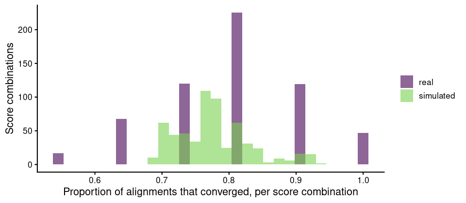

```r
ggplot(conv, aes(converged, fill = data.type)) +
  geom_histogram(bins = 30, position = "identity", alpha = 0.6) +
  scale_fill_viridis_d(end = 0.8, name = NULL) +
  labs(x = "Proportion of alignments that converged, per score combination", y = "Score combinations")
```

# 5 Results

## 5.1 What MAFFT responds to

Different scores can give exactly the same alignments, as MAFFT appears to rescale the matrix before using it (scores with the same value of $r$ give identical results for 77 of the 79 values of $r$, with small differences for the other two). What is left is essentially a single number, the **position of the same-category score between the other two**:

$$r = \frac{\text{same.category} - \text{different.category}}{\text{same.state} - \text{different.category}}$$

Low values of $r$ treat different states of the same category almost as mismatches, while high values treat them almost as matches. For example, the scores (0.5, 1.25, 2) and (0, 1, 2) both have $r$ = 0.5 and give the same alignments.

Combinations with a score of exactly -1 are excluded: MAFFT handles this value differently, giving different alignments from equivalent scores (and from -1.001, which behaves as expected).

```r
add_r <- function(d) {
  d$r <- round((d$same.category - d$different.category) / (d$same.state - d$different.category), 4)
  d$has_minus1 <- d$different.category == -1 | d$same.category == -1
  d
}

all_aln$gap_diff_converged <- conv_aln$gap_diff[match(all_aln$cost.vals, conv_aln$cost.vals)]
all_aln <- add_r(all_aln)
valid <- all_aln[!all_aln$has_minus1, ]

by_r <- do.call(rbind, lapply(split(valid, valid$r), function(z)
  data.frame(r = z$r[1], combinations = nrow(z), gaps_real = mean(z$gaps_real), gaps_sim = mean(z$gaps_sim),
             gap_diff = mean(z$gap_diff), se = mean(z$se), gap_diff_converged = mean(z$gap_diff_converged, na.rm = TRUE),
             prop_diff = mean(z$prop_diff), example = z$cost.vals[1])))
rownames(by_r) <- NULL

data.frame(combinations = nrow(all_aln), with_a_score_of_minus_1 = sum(all_aln$has_minus1), used = nrow(valid),
           distinct_values_of_r = nrow(by_r))
```

| combinations | with_a_score_of_minus_1 | used | distinct_values_of_r |
| --- | --- | --- | --- |
| 596 | 92 | 504 | 79 |

## 5.2 Gaps across values of r

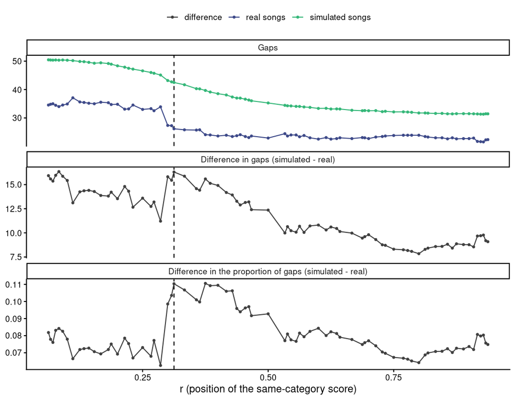

```r
two_se <- 2 * by_r$se[which.max(by_r$gap_diff)]
candidates <- by_r[by_r$gap_diff >= max(by_r$gap_diff) - two_se, ]
selected <- candidates[which.max(candidates$prop_diff), ]

panel <- rbind(data.frame(r = by_r$r, value = by_r$gaps_real, series = "real songs", panel = "Gaps"),
               data.frame(r = by_r$r, value = by_r$gaps_sim, series = "simulated songs", panel = "Gaps"),
               data.frame(r = by_r$r, value = by_r$gap_diff, series = "difference", panel = "Difference in gaps (simulated - real)"),
               data.frame(r = by_r$r, value = by_r$prop_diff, series = "difference", panel = "Difference in the proportion of gaps (simulated - real)"))
panel$panel <- factor(panel$panel, c("Gaps", "Difference in gaps (simulated - real)", "Difference in the proportion of gaps (simulated - real)"))

ggplot(panel, aes(r, value, color = series)) +
  geom_vline(xintercept = selected$r, linetype = 2) +
  geom_line() + geom_point(size = 1) +
  scale_color_manual(values = c("real songs" = viridis(10)[3], "simulated songs" = viridis(10)[7], "difference" = "gray25"), name = NULL) +
  facet_wrap(~ panel, ncol = 1, scales = "free_y") +
  labs(x = "r (position of the same-category score)", y = NULL) + theme(legend.position = "top")
```

The dashed line marks the selected value. The largest differences in gaps occur in two regions. At very low values of $r$, alignments are full of gaps for both real and simulated songs, as the number of columns added is about as long as the songs themselves. At values of $r$ around 0.3 to 0.4, the difference is just as large but real songs need far fewer gaps.

## 5.3 Selection rule

The number of gaps alone can favour scores that fill all alignments with gaps, as this leaves more room for a large difference. For this reason, and after inspecting the results above, we selected the scores in two steps:

1. Keep the values of $r$ whose difference in gaps is within 2 standard errors of the largest one (0.63 gaps; standard errors come from the variation among simulated sets)
2. Among these, select the one with the largest difference in the proportion of gaps

```r
data.frame(r = candidates$r, example_scores = candidates$example, gaps_real = round(candidates$gaps_real, 1),
           gaps_simulated = round(candidates$gaps_sim, 1), gap_difference = round(candidates$gap_diff, 2),
           gap_difference_converged = round(candidates$gap_diff_converged, 2), proportion_difference = round(candidates$prop_diff, 3),
           selected = ifelse(candidates$r == selected$r, "yes", ""))
```

| r | example_scores | gaps_real | gaps_simulated | gap_difference | gap_difference_converged | proportion_difference | selected |
| --- | --- | --- | --- | --- | --- | --- | --- |
| 0.0625 | -2_-1.75_2 | 34.5 | 50.5 | 15.93 | 13.51 | 0.082 |  |
| 0.0769 | -1.5_-1.25_1.75 | 34.5 | 50.4 | 15.96 | 14.99 | 0.083 |  |
| 0.0833 | -1.5_-1.25_1.5 | 34.0 | 50.3 | 16.35 | 15.06 | 0.084 |  |
| 0.0909 | -0.75_-0.5_2 | 34.5 | 50.4 | 15.87 | 13.72 | 0.083 |  |
| 0.3000 | -0.5_0.25_2 | 27.4 | 43.2 | 15.81 | 15.13 | 0.099 |  |
| 0.3125 | -2_-0.75_2 | 26.2 | 42.5 | 16.30 | 15.33 | 0.110 | yes |
| 0.3333 | -0.25_0_0.5 | 25.8 | 41.7 | 15.87 | 15.67 | 0.107 |  |

## 5.4 How robust is the choice?

The values of $r$ preferred by each criterion, and the position of the selected value in each ranking:

```r
paper <- add_r(score(res[res$lek %in% paper_leks, ]))
paper <- paper[!paper$has_minus1, ]
paper_r <- aggregate(cbind(gap_diff, prop_diff) ~ r, paper, mean)

rob <- list("difference in gaps, all alignments, 11 leks" = setNames(by_r$gap_diff, by_r$r),
            "difference in gaps, only converged, 11 leks" = setNames(by_r$gap_diff_converged, by_r$r),
            "difference in proportion of gaps, 11 leks" = setNames(by_r$prop_diff, by_r$r),
            "difference in gaps, five leks in the paper" = setNames(paper_r$gap_diff, paper_r$r),
            "difference in proportion of gaps, five leks in the paper" = setNames(paper_r$prop_diff, paper_r$r))

do.call(rbind, lapply(names(rob), function(n) {
  v <- sort(rob[[n]], decreasing = TRUE)
  data.frame(criterion = n, best_r = names(v)[1], value_at_best_r = round(v[1], 3), value_at_selected_r = round(v[as.character(selected$r)], 3),
             rank_of_selected_r = match(as.character(selected$r), names(v)), out_of = length(v), row.names = NULL)
}))
```

| criterion | best_r | value_at_best_r | value_at_selected_r | rank_of_selected_r | out_of |
| --- | --- | --- | --- | --- | --- |
| difference in gaps, all alignments, 11 leks | 0.0833 | 16.347 | 16.305 | 2 | 79 |
| difference in gaps, only converged, 11 leks | 0.3846 | 17.430 | 15.332 | 8 | 79 |
| difference in proportion of gaps, 11 leks | 0.375 | 0.111 | 0.110 | 2 | 79 |
| difference in gaps, five leks in the paper | 0.0909 | 21.022 | 19.718 | 4 | 79 |
| difference in proportion of gaps, five leks in the paper | 0.3125 | 0.112 | 0.112 | 1 | 79 |

# 6 Adopted scores

We adopted **r = 0.3125**, using **different category = -2, same category = -0.75, same state = 2** for the “optimal” alignment strategy. With these scores, real songs need 26.2 gaps on average and simulated songs need 42.5, a difference of 16.3 gaps.

Values of $r$ from about 0.31 to 0.40 perform similarly, so the choice does not depend on the exact value within this range. The criterion shows that the scores separate real from simulated songs, not that the resulting alignments are biologically correct.

Gaps per lek with these scores:

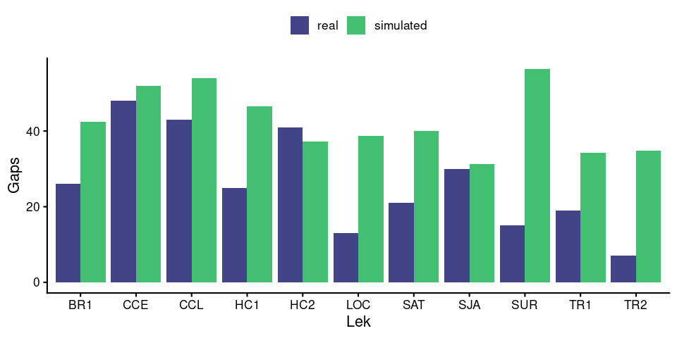

```r
sel <- res[res$cost.vals == selected$example, ]
sel_lek <- aggregate(gaps ~ lek + data.type, sel, mean)

ggplot(sel_lek, aes(lek, gaps, fill = data.type)) +
  geom_col(position = "dodge") +
  scale_fill_viridis_d(begin = 0.2, end = 0.7, name = NULL) +
  labs(x = "Lek", y = "Gaps") + theme(legend.position = "top")
```

Score matrix used by MAFFT, saved as `data/processed/mafft_alignments_5ms/optimal_cost_matrix.txt`:

```r
best <- parse_costs(data.frame(cost.vals = selected$example, stringsAsFactors = FALSE))
states <- c("d", "p", "u", "f", "s")
hex <- c(d = "0x64", f = "0x66", p = "0x70", s = "0x73", u = "0x75")
pairs <- expand.grid(a = states, b = states, stringsAsFactors = FALSE)
trills <- c("f", "s")
pairs$score <- ifelse(pairs$a == pairs$b, best$same.state,
                      ifelse((pairs$a %in% trills) == (pairs$b %in% trills), best$same.category, best$different.category))

xtabs(score ~ a + b, pairs)
```

```
   b
a       d     f     p     s     u
  d  2.00 -2.00 -0.75 -2.00 -0.75
  f -2.00  2.00 -2.00 -0.75 -2.00
  p -0.75 -2.00  2.00 -2.00 -0.75
  s -2.00 -0.75 -2.00  2.00 -2.00
  u -0.75 -2.00 -0.75 -2.00  2.00
```

```r
if (complete) {
  out <- "./data/processed/mafft_alignments_5ms"
  dir.create(out, showWarnings = FALSE)
  writeLines(sprintf("%s %s %.2f", hex[pairs$a], hex[pairs$b], pairs$score), file.path(out, "optimal_cost_matrix.txt"))
  write.csv(all_aln[, c("cost.vals", "different.category", "same.category", "same.state", "r", "has_minus1", "gaps_real", "gaps_sim",
                        "gap_diff", "se", "gap_diff_converged", "prop_diff")],
            file.path(in_dir, "cost_optimization_results.csv"), row.names = FALSE)
}
```

# 7 Aligning the song sequences

Alignments are made in `source/align_song_types_5ms.R`, for the five leks in the paper. Each song type has one sequence, the one in its most representative recording, which is shared by all its years (FASTA files in `data/processed/song_sequences_5ms/song_type_sequence`). The scores above were optimized on the same kind of data.

## 7.1 Alignment strategies

| Strategy | File name | Method |
| --- | --- | --- |
| MAFFT-optimal | `optimal` | MAFFT L-INS-i, with the adopted scores (-2, -0.75, 2) |
| MAFFT-agnostic | `all.equal` | MAFFT L-INS-i, with the same score for any mismatch (1, 1, 1.5) |
| PRANK | `prank` | PRANK v.170427, with `-iterate=100 -kappa=2`, writing states as nucleotides (f = C, s = T, u = A, d = G, p = R). Selected among 100 seeds, as explained below |

MAFFT alignments use `mafft --localpair --maxiterate 50000 --textmatrix` (v7.526).

## 7.2 Datasets

Each song type is aligned once, using a base alignment with a single row per song type. The datasets for the analyses are then built from this alignment, with each year taking the aligned row of its song type:

- **`all`**: all the years in which a song type was recorded
- **`bounds`**: only the first and last year of each song type

The two datasets therefore have identical aligned rows and differ only in the years included. There are two versions of the historical records: `new` includes recordings after 2000 and `old` also includes the earlier ones, for the three leks that have them. Finally, `no.fossils` has only the song types of the last year of sampling, aligned on their own, for the leks with more than 3 song types in that year.

The base alignment is not analyzed on its own: as it counts each song type only in its first year, it misses song types that persist until the last year of sampling. This would contradict the assumption that all songs present in that year were sampled. Both `all` and `bounds` keep the same songs in the last year:

```r
aln_dir <- "./data/processed/mafft_alignments_5ms"

read_fa <- function(file) {
  a <- readLines(file)
  starts <- grep("^>", a)
  s <- mapply(function(i, j) paste(a[(i + 1):j], collapse = ""), starts, c(starts[-1] - 1, length(a)))
  s <- setNames(as.vector(s), sub("^>", "", a[starts]))
  s[order(names(s))]
}

aln_file <- function(lek, strategy, set) file.path(aln_dir, paste0(lek, "_", strategy, "_", set, "_alignment.fa"))
taxon_year <- function(x) as.numeric(sub("^.*-", "", x))

datasets <- do.call(rbind, lapply(c("new", "old"), function(f) do.call(rbind, lapply(paper_leks, function(l) {
  if (!file.exists(aln_file(l, "optimal", paste0("all_", f)))) return(NULL)
  n <- lapply(c("early", "bounds", "all"), function(s) names(read_fa(aln_file(l, "optimal", paste0(s, "_", f)))))
  last <- max(taxon_year(n[[3]]))
  data.frame(lek = l, records = f, song_types = length(n[[1]]), taxa_bounds = length(n[[2]]), taxa_all = length(n[[3]]),
             last_year = last, last_year_base = sum(taxon_year(n[[1]]) == last),
             last_year_bounds = sum(taxon_year(n[[2]]) == last), last_year_all = sum(taxon_year(n[[3]]) == last))
}))))

datasets
```

| lek | records | song_types | taxa_bounds | taxa_all | last_year | last_year_base | last_year_bounds | last_year_all |
| --- | --- | --- | --- | --- | --- | --- | --- | --- |
| BR1 | new | 12 | 17 | 23 | 2014 | 5 | 9 | 9 |
| CCE | new | 9 | 13 | 25 | 2018 | 2 | 2 | 2 |
| HC1 | new | 6 | 9 | 12 | 2013 | 0 | 3 | 3 |
| SUR | new | 24 | 37 | 65 | 2019 | 2 | 5 | 5 |
| TR1 | new | 13 | 21 | 33 | 2014 | 1 | 8 | 8 |
| CCE | old | 21 | 30 | 51 | 2018 | 2 | 2 | 2 |
| HC1 | old | 20 | 24 | 31 | 2013 | 0 | 3 | 3 |
| SUR | old | 38 | 58 | 100 | 2019 | 2 | 5 | 5 |

## 7.3 PRANK across seeds

Unlike MAFFT, PRANK gives different alignments in different runs. We therefore ran it with 100 seeds on each set (`source/prank_seeds_5ms.R`). After inspecting the results, we kept the most **central** alignment: the one sharing the most aligned pairs of states with the alignments from all other seeds.

Similarity between two alignments is the proportion of aligned pairs of states they have in common (1 means identical). PRANK’s own score is a penalty, as each run keeps its lowest-scoring iteration, but we did not use it for selection: its best value was often reached only once in 100 runs, and it favoured alignments with many gaps. Selecting by centrality was also more repeatable, as shown by comparing the alignments selected from seeds 1-50 and 51-100:

```r
prank_sel <- read.csv(file.path(aln_dir, "prank_seeds", "prank_selection.csv"), stringsAsFactors = FALSE)

data.frame(set = prank_sel$set, different_alignments = prank_sel$distinct_alignments, mean_similarity = round(prank_sel$mean_similarity, 2),
           selected_seed = prank_sel$selected_seed, gaps_selected = prank_sel$gaps,
           gaps_range = paste(prank_sel$gaps_min, prank_sel$gaps_max, sep = " - "),
           repeatability_central = round(prank_sel$split_half_central, 2), repeatability_lowest_score = round(prank_sel$split_half_lowest_score, 2))
```

| set | different_alignments | mean_similarity | selected_seed | gaps_selected | gaps_range | repeatability_central | repeatability_lowest_score |
| --- | --- | --- | --- | --- | --- | --- | --- |
| early_new_BR1 | 88 | 0.30 | 21 | 47 | 29 - 73 | 0.58 | 0.28 |
| early_new_CCE | 2 | 0.92 | 1 | 11 | 7 - 11 | 1.00 | 1.00 |
| early_new_HC1 | 5 | 0.95 | 1 | 8 | 8 - 8 | 1.00 | 1.00 |
| early_new_SUR | 100 | 0.21 | 81 | 33 | 21 - 56 | 0.38 | 0.12 |
| early_new_TR1 | 12 | 0.51 | 3 | 33 | 20 - 33 | 0.99 | 0.22 |
| early_old_CCE | 100 | 0.09 | 8 | 83 | 38 - 108 | 0.31 | 0.17 |
| early_old_HC1 | 100 | 0.14 | 61 | 19 | 9 - 70 | 0.45 | 0.08 |
| early_old_SUR | 100 | 0.12 | 52 | 40 | 28 - 96 | 0.31 | 0.18 |
| no.fossils_BR1 | 44 | 0.30 | 7 | 46 | 22 - 56 | 1.00 | 0.23 |
| no.fossils_SUR | 1 | 1.00 | 1 | 0 | 0 - 0 | 1.00 | 1.00 |
| no.fossils_TR1 | 1 | 1.00 | 1 | 1 | 1 - 1 | 1.00 | 1.00 |

On average, repeatability is 0.73 for the central alignment and 0.48 for the lowest score. The selected alignment is only one of many possibilities in the sets with low similarity, particularly those with `old` records. Results that appear only with PRANK in these sets should be interpreted with care.

## 7.4 Results

The base and `no.fossils` alignments of each strategy, with their similarity to the MAFFT-optimal alignment:

```r
aln_res <- read.csv(file.path(aln_dir, "alignment_results.csv"), stringsAsFactors = FALSE)
direct <- aln_res[aln_res$set %in% c("early_new", "early_old", "no.fossils"), ]
sets <- unique(direct[, c("lek", "set")])
sets <- sets[order(factor(sets$set, c("early_new", "early_old", "no.fossils")), sets$lek), ]

# aligned pairs of states, as integer keys: state r of song i aligned with state s of song j
pairs_of <- function(a) {
  m <- do.call(rbind, strsplit(a, ""))
  r <- t(apply(m != "-", 1, cumsum))
  r[m == "-"] <- 0
  unlist(lapply(seq_len(ncol(m)), function(cl) {
    w <- which(r[, cl] > 0)
    if (length(w) < 2) return(NULL)
    p <- combn(w, 2)
    (p[1, ] - 1) * 1e6 + (p[2, ] - 1) * 1e4 + (r[p[1, ], cl] - 1) * 100 + (r[p[2, ], cl] - 1)
  }))
}

similarity <- function(a, b) {
  x <- pairs_of(a); y <- pairs_of(b)
  k <- length(intersect(x, y))
  k / (length(x) + length(y) - k)
}

comparison <- do.call(rbind, lapply(seq_len(nrow(sets)), function(i) {
  l <- sets$lek[i]; s <- sets$set[i]
  g <- function(strategy, v) direct[direct$lek == l & direct$set == s & direct$strategy == strategy, v]
  optimal <- read_fa(aln_file(l, "optimal", s))
  data.frame(lek = l, set = sub("early_", "base_", s), taxa = g("optimal", "taxa"), longest_song = g("optimal", "aln_len") - g("optimal", "gaps"),
             gaps_optimal = g("optimal", "gaps"), gaps_agnostic = g("all.equal", "gaps"), gaps_prank = g("prank", "gaps"),
             converged_optimal = ifelse(g("optimal", "converged"), "yes", "no"), converged_agnostic = ifelse(g("all.equal", "converged"), "yes", "no"),
             similarity_to_agnostic = round(similarity(optimal, read_fa(aln_file(l, "all.equal", s))), 2),
             similarity_to_prank = round(similarity(optimal, read_fa(aln_file(l, "prank", s))), 2))
}))

comparison
```

| lek | set | taxa | longest_song | gaps_optimal | gaps_agnostic | gaps_prank | converged_optimal | converged_agnostic | similarity_to_agnostic | similarity_to_prank |
| --- | --- | --- | --- | --- | --- | --- | --- | --- | --- | --- |
| BR1 | base_new | 12 | 34 | 26 | 38 | 47 | no | yes | 0.49 | 0.23 |
| CCE | base_new | 9 | 37 | 16 | 39 | 11 | yes | no | 0.17 | 0.14 |
| HC1 | base_new | 6 | 31 | 30 | 21 | 8 | yes | yes | 0.17 | 0.11 |
| SUR | base_new | 24 | 38 | 18 | 39 | 33 | yes | yes | 0.28 | 0.10 |
| TR1 | base_new | 13 | 32 | 19 | 23 | 33 | no | no | 0.39 | 0.09 |
| CCE | base_old | 21 | 37 | 48 | 48 | 83 | yes | yes | 0.25 | 0.14 |
| HC1 | base_old | 20 | 31 | 25 | 31 | 19 | no | no | 0.22 | 0.09 |
| SUR | base_old | 38 | 38 | 15 | 32 | 40 | yes | yes | 0.20 | 0.05 |
| BR1 | no.fossils | 9 | 34 | 24 | 28 | 46 | yes | yes | 0.47 | 0.12 |
| SUR | no.fossils | 5 | 38 | 0 | 17 | 0 | yes | yes | 0.17 | 0.48 |
| TR1 | no.fossils | 8 | 27 | 1 | 14 | 1 | yes | yes | 0.70 | 0.17 |

```r
mean_comparison <- colMeans(comparison[, c("gaps_optimal", "gaps_agnostic", "gaps_prank", "similarity_to_agnostic", "similarity_to_prank")])
aggregate(gap_prop ~ strategy, direct, function(x) round(mean(x), 2))
```

| strategy | gap_prop |
| --- | --- |
| all.equal | 0.56 |
| optimal | 0.47 |
| prank | 0.51 |

MAFFT-optimal needs fewer gaps on average (20.2) than MAFFT-agnostic (30) and PRANK (29.2). However, the strategies give quite different alignments: the mean similarity of MAFFT-optimal is 0.32 to MAFFT-agnostic and 0.16 to PRANK. Having fewer gaps does not show that an alignment is correct, so using all three strategies shows which results depend on the alignment.

6 of the 22 direct MAFFT alignments did not report convergence with 50,000 iterations. PRANK does not report this.

## 7.5 Alignments

The base alignments with `new` records, using the same state colors as the song segmenting report. White cells are gaps:

**BR1**

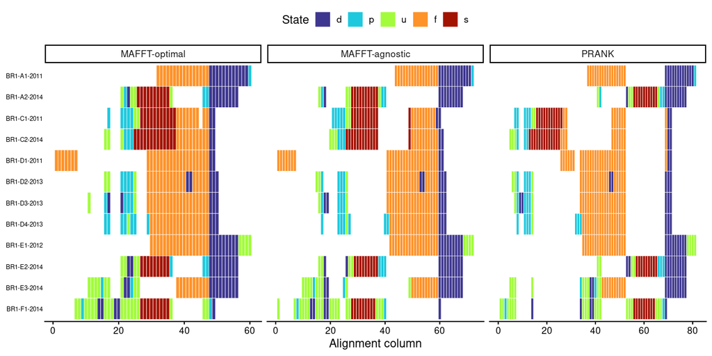

**CCE**

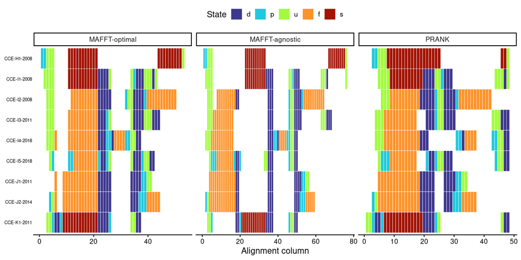

**HC1**

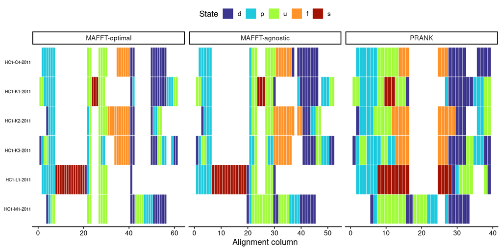

**SUR**

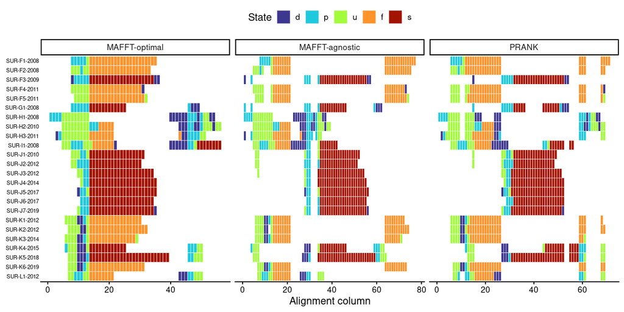

**TR1**

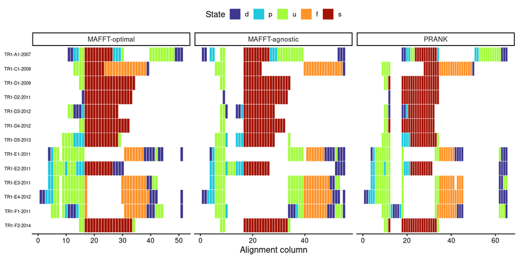

## 7.6 Nexus files

The datasets are saved as nexus files for RevBayes (`source/write_nexus_5ms.R`), with `symbols="dfpsu"` and PRANK alignments converted back to song states. There is one file per lek, strategy and dataset, for a total of 57:

```r
nex <- list.files("./data/processed/nexus_5ms", pattern = "\\.nex$")
as.data.frame.matrix(table(strategy = sub("^[A-Z0-9]+_([a-z.]+)_.*$", "\\1", nex), dataset = sub("^[A-Z0-9]+_[a-z.]+_(.*)_alignment\\.nex$", "\\1", nex)))
```

|  | all_new | all_old | bounds_new | bounds_old | no.fossils |
| --- | --- | --- | --- | --- | --- |
| all.equal | 5 | 3 | 5 | 3 | 3 |
| optimal | 5 | 3 | 5 | 3 | 3 |
| prank | 5 | 3 | 5 | 3 | 3 |

With two clock models (global and relaxed), this gives 114 models in RevBayes.

## 7.7 Output files

| File | Location |
| --- | --- |
| Nexus files | `data/processed/nexus_5ms/` |
| Alignments (FASTA) and scoring matrices | `data/processed/mafft_alignments_5ms/` |
| Alignment results and checks | `data/processed/mafft_alignments_5ms/alignment_results.csv` |
| PRANK runs and selection | `data/processed/mafft_alignments_5ms/prank_seeds/` |
| Results for each score combination | `data/processed/mafft_optimization_5ms/cost_optimization_results.csv` |

# 8 Changes from the previous version

- **Five states**: state m no longer exists, so trills are f and s
- **Song lengths**: songs now differ in length, so gaps are counted from the longest song, and simulated leks copy the song lengths of the real lek
- **Selection of the MAFFT scores**: the number of gaps is combined with the proportion of gaps, and results are summarized by $r$
- **Convergence in the score optimization**: results use all alignments, with converged alignments shown for comparison
- **PRANK**: the most central alignment among 100 seeds, instead of a single run
- **Later years of a song type**: they take the aligned row of their song type, instead of being added with `mafft --add`, which realigns each copy on its own and can place identical songs in different columns
- **Datasets**: `bounds` replaces the dataset with only the earliest occurrence of each song type